# List of sampling methods

TODO: - Description of the full factorial sampling and clustered sampling - Debug clustered sampling in the next section

- Random sampling

This class creates random samples from a uniform distribution over the design space.

- Latin hypercube sampling (LHS)

The LHS design is a statistical method for generating a quasi-random sampling distribution. It is among the most popular sampling techniques in computer experiments thanks to its simplicity and projection properties with high-dimensional problems. LHS is built as follow: we cut each dimension space, wich represents a variable, into $n$ sections with $n$ is the number of sampling points, and we put only one point in each section.

[figure not shown]

The figure above gives us an example of an LHS design with 2 variables $x1$ and $x2$ where each column from $x1$-axis and each row from $x2$-axis contain only one point.

The LHS method uses the pyDOE package (Design of Experiments for Python) which is available on https://pythonhosted.org/pyDOE/index.html. 5 criteria for the construction of LHS are implemented in SMT: - Center the points within the sampling intervals. - Maximize the minimum distance between points and place the point in a randomized location within its interval. - Maximize the minimum distance between points and center the point within its interval. - Minimize the maximum correlation coefficient. - Optimize the design using the Enhanced Stochastic Evolutionary algorithm (ESE).

The four first criteria are the same than in pyDOE (for more details, see https://pythonhosted.org/pyDOE/index.html). The last criterion, ESE, is implemented by the authors of SMT (more details about such method could be found in [1]).

[1] R. Jin, W. Chen and A. Sudjianto (2005), "An efficient algorithm for constructing optimal design of computer experiments." Journal of Statistical Planning and Inference, 134:268-287.

- Full factorial sampling

- Clustered sampling

# Example of execution

- Random sampling

```
[[ 0.28935936  0.77856159]
 [ 0.39419707  0.56807521]
 [ 0.9247589  -0.447105  ]
 [ 0.91952191  0.99823195]
 [-0.93197996 -0.02421645]
 [-0.98626353 -0.31546731]
 [ 0.38435626  0.02200552]
 [ 0.69582881  0.34469685]
 [-0.84066389  0.26939173]
 [-0.43274028 -0.77212883]
 [ 0.54369442 -0.6896355 ]
 [ 0.23949909 -0.9091708 ]
 [-0.56180202 -0.90728748]
 [-0.34413767  0.21561072]
 [-0.18372821 -0.80790307]
 [-0.8547607  -0.83767742]
 [ 0.42070647 -0.9742728 ]
 [-0.4293445  -0.68290183]
 [-0.21439163 -0.85118039]
 [ 0.28502652 -0.77236119]]
```

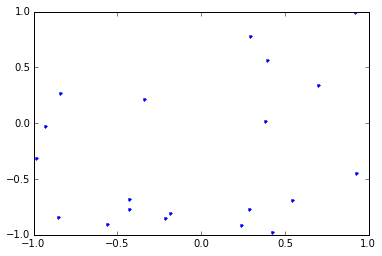

```python
# Import the random sampling method
from smt.sampling import Random
import numpy as np
import matplotlib.pyplot as plt
%matplotlib inline

# Define the bounds of the design space , the number of dimension, and the number of sampling points
dim, ndoe = 2, 20
xlimits = np.zeros((dim, 2))
xlimits[:, 0] = -1
xlimits[:, 1] = 1

# Construct the Random sampling points and store into x
sampling = Random(xlimits = xlimits)
x = sampling(ndoe)

# Print results
print(x)
plt.figure()
plt.plot(x[:,0],x[:,1],'.')
plt.show()
```

- Latin hypercube sampling (LHS)

```
[[ 0.64524292 -0.29743303]
 [-0.0204177   0.92019059]
 [ 0.8354098   0.19509246]
 [-0.88957522  0.58885892]
 [ 0.79773098  0.69044532]
 [ 0.50005119 -0.93006306]
 [-0.3965959  -0.37489526]
 [ 0.21564176 -0.50386742]
 [ 0.02865156  0.44491897]
 [-0.14773073 -0.79682888]
 [ 0.97929667 -0.64094207]
 [-0.41578805  0.85301762]
 [ 0.38205573  0.73199736]
 [-0.79158846 -0.08366045]
 [-0.93515755 -0.47800584]
 [ 0.16252521 -0.11324254]
 [ 0.40206543  0.21903496]
 [-0.51925093  0.34511377]
 [-0.21742045  0.01388376]
 [-0.66458875 -0.84230409]]
```

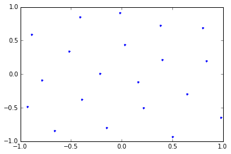

```python
# Import the LHS sampling method
from smt.sampling import LHS
import numpy as np
import matplotlib.pyplot as plt
%matplotlib inline

# Define the bounds of the design space , the number of dimension, and the number of sampling points
dim, ndoe = 2, 20
xlimits = np.zeros((dim, 2))
xlimits[:, 0] = -1
xlimits[:, 1] = 1

# Construct the LHS sampling points with 'ese' criterion and store into x
sampling = LHS(xlimits = xlimits, criterion = 'ese')
x = sampling(ndoe)

# Print results
print(x)
plt.figure()
plt.plot(x[:,0],x[:,1],'.')
plt.show()
```

- Full factorial sampling

```
[[-1.         -1.        ]
 [-1.         -0.33333333]
 [-1.          0.33333333]
 [-1.          1.        ]
 [-0.5        -1.        ]
 [-0.5        -0.33333333]
 [-0.5         0.33333333]
 [-0.5         1.        ]
 [ 0.         -1.        ]
 [ 0.         -0.33333333]
 [ 0.          0.33333333]
 [ 0.          1.        ]
 [ 0.5        -1.        ]
 [ 0.5        -0.33333333]
 [ 0.5         0.33333333]
 [ 0.5         1.        ]
 [ 1.         -1.        ]
 [ 1.         -0.33333333]
 [ 1.          0.33333333]
 [ 1.          1.        ]]
```

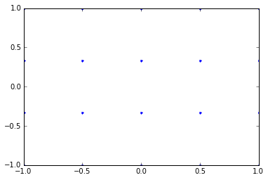

```python
# Import the full factorial sampling method
from smt.sampling import FullFactorial
import numpy as np
import matplotlib.pyplot as plt
%matplotlib inline

# Define the bounds of the design space , the number of dimension, and the number of sampling points
dim, ndoe = 2, 20
xlimits = np.zeros((dim, 2))
xlimits[:, 0] = -1
xlimits[:, 1] = 1

# Construct the full factorial sampling points and store into x
sampling = FullFactorial(xlimits = xlimits)
x = sampling(ndoe)

# Print results
print(x)
plt.figure()
plt.plot(x[:,0],x[:,1],'.')
plt.show()
```

- Clustered sampling

```python
# Import the clustered sampling method
from smt.sampling import Clustered
import numpy as np
import matplotlib.pyplot as plt
%matplotlib inline

# Define the bounds of the design space , the number of dimension, and the number of sampling points
dim, ndoe = 2, 20
xlimits = np.zeros((dim, 2))
xlimits[:, 0] = -1
xlimits[:, 1] = 1

# Construct the clustered sampling points and store into x
sampling = Clustered(xlimits = xlimits)
x = sampling(ndoe)

# Print results
print(x)
plt.figure()
plt.plot(x[:,0],x[:,1],'.')
plt.show()
```

[output not shown]